# Supplement: Amount and time exert independent influences on intertermporal choice

```r
setwd("C:/Users/User/GitHub/WebET_Analysis")
getPackages <- function(pkg){
  new.pkg <- pkg[!(pkg %in% installed.packages()[, "Package"])]
  if (length(new.pkg))
    install.packages(new.pkg, dependencies = TRUE)
  sapply(pkg, require, character.only = TRUE)
}

getPackages(c('plyr',
              'dplyr',

              "effsize",
              'e1071',
              "ggplot2",
              "ggsignif",
              'matlabr',
              'QuantPsyc',
              "RColorBrewer",
              'reshape2',
              'tidyr')
            )
```

```
##         plyr        dplyr      effsize        e1071      ggplot2     ggsignif
##         TRUE         TRUE         TRUE         TRUE         TRUE         TRUE
##      matlabr    QuantPsyc RColorBrewer     reshape2        tidyr
##         TRUE         TRUE         TRUE         TRUE         TRUE
```

# Matlab

```r
run_matlab_script('amasino_dataPrep/fit_discount_k.m')
```

```
## Command run is:
```

```
## matlab.exe -wait -nodesktop -nosplash -nodisplay -r  "try, run('amasino_dataPrep/fit_discount_k.m'); catch err, disp(err.message); exit(1); end; exit(0);"
```

```
## [1] 0
```

# Cleaning

see choice_analysis.Rmd

# Read and create datasets

## Exclude subjects

```r
# Data on subject level
excludeSubjects <- read.table('data_jupyter/excludeSubjects_choice.csv',
                           header=TRUE, sep=',')[, 1]
excludeSubjects
```

```
##  [1]   70   72    9 1020   14 2002   83   88 2008 2011   99 1001  106 1002  108
## [16] 1007   49 1009 1015   54 1014 1016 1017 1019  124  125 1022
```

## data_subject

```r
# Data on subject level
data_subject <- read.table('data_jupyter/data_subject.csv',
                           header=TRUE, sep=',') %>%
    filter(!(run_id %in% excludeSubjects))
alllogk<-read.table(
    "amasino_dataPrep/intermediateCSVs/allLogk.csv", header=FALSE, sep=",")
names(alllogk) = c('run_id', 'logK')
data_subject = merge(data_subject, alllogk, by='run_id')
data_subject = data_subject %>%
    filter(!is.na(logK))
print(nrow(data_subject))
```

```
## [1] 44
```

```r
data_subject
```

| run_id | birthyear | browliner | browser | browser_version | degree | device | ethnic | eyeliner | eyeshadow | gender | glasses | keptHead | masquara | optionalNote | platform | platform_version | sight | triedChin | user_agent | vertPosition | webcam_fps | webcam_height | webcam_label | webcam_width | chinFirst | choiceTask_amountLeftFirst | chosenAmount | chosenDelay | prolificID | … |
| --- | --- | --- | --- | --- | --- | --- | --- | --- | --- | --- | --- | --- | --- | --- | --- | --- | --- | --- | --- | --- | --- | --- | --- | --- | --- | --- | --- | --- | --- | --- |
| 1 | 1995 | 0 | Chrome | 87.0.4280.141 | highSchool | WebKit | caucasian | 0 | 0 | male | shortSight | 1 | 0 |  | Windows | 10.0 | glasses | 1 | Mozilla/5.0 (Windows NT 10.0; Win64; x64) AppleWebKit/537.36 (KHTML, like Gecko) Chrome/87.0.4280.141 Safari/537.36 | a | 30 | 480 | Microsoft LifeCam VX-3000 (045e:00f5) | 640 | 1 | 0 |  |  | 5fccc8ac636416a4288a9f3d | … |
| 4 | 1997 | 0 | Chrome | 87.0.4280.141 | grad | WebKit | caucasian | 0 | 0 | male | longSight | 1 | 0 |  | Windows | 10.0 | glasses | 1 | Mozilla/5.0 (Windows NT 10.0; Win64; x64) AppleWebKit/537.36 (KHTML, like Gecko) Chrome/87.0.4280.141 Safari/537.36 | a | 30 | 480 | Logitech HD Webcam C270 (046d:0825) | 640 | 0 | 1 | $4.5 | 30 days | 5f96fc2552ce3f040af63bbc | … |
| 5 | 1994 | 0 | Chrome | 87.0.4280.88 | college | Macintosh | caucasian | 0 | 0 | female | shortSight | 1 | 0 |  | OS X | 10_15_7 | contactLenses | 1 | Mozilla/5.0 (Macintosh; Intel Mac OS X 10_15_7) AppleWebKit/537.36 (KHTML, like Gecko) Chrome/87.0.4280.88 Safari/537.36 | b | 30 | 480 | FaceTime HD Camera (Built-in) (05ac:8514) | 640 | 1 | 1 | $4.5 | 30 days | 5ea3f75481a44e39aa318256 | … |
| 6 | 2001 | 0 | Firefox | 84.0 |  |  | caucasian | 0 | 0 | male | noCorrection | 1 | 0 |  | Ubuntu |  | perfectSight | 1 | Mozilla/5.0 (X11; Ubuntu; Linux x86_64; rv:84.0) Gecko/20100101 Firefox/84.0 | b | 30 | 480 | TOSHIBA Web Camera - HD: TOSHIB | 640 | 0 | 0 | $5 | 15 days | 5f4e08aafb74230a29cb4ef0 | … |
| 7 | 1994 | 0 | Chrome | 87.0.4280.141 | highSchool | WebKit | hispanic | 0 | 0 | male | longSight | 1 | 0 | I believe I stayed still but maybe a moved a little | Windows | 10.0 | contactLenses | 1 | Mozilla/5.0 (Windows NT 10.0; Win64; x64) AppleWebKit/537.36 (KHTML, like Gecko) Chrome/87.0.4280.141 Safari/537.36 | a | 30 | 480 | HD Pro Webcam C920 (046d:0892) | 640 | 0 | 1 | $4 | 30 days | 5fd41bf508717e1833d8aed7 | … |
| 11 | 1991 | 0 | Chrome | 87.0.4280.141 | college | WebKit | asian | 0 | 0 | male | shortSight | 1 | 0 |  | Windows | 10.0 | glasses | 1 | Mozilla/5.0 (Windows NT 10.0; Win64; x64) AppleWebKit/537.36 (KHTML, like Gecko) Chrome/87.0.4280.141 Safari/537.36 | a | 30 | 480 | Lenovo EasyCamera (174f:14e8) | 640 | 0 | 1 | $3.5 | Today | 5c5684ef9d244c0001b29f1e | … |
| 13 | 2001 | 0 | Opera | 72.0.3815.465 | highSchool | WebKit | caucasian | 0 | 0 | male | noCorrection | 1 | 0 |  | Windows | 10.0 | perfectSight | 1 | Mozilla/5.0 (Windows NT 10.0; Win64; x64) AppleWebKit/537.36 (KHTML, like Gecko) Chrome/86.0.4240.198 Safari/537.36 OPR/72.0.3815.465 | c | 30 | 480 | USB2.0 HD UVC WebCam (13d3:56a2) | 640 | 1 | 0 | $5 | 30 days | 5b4e65de09f5af0001080f45 | … |
| 19 | 2000 | 0 | Chrome | 87.0.4280.141 | highSchool | WebKit | caucasian | 0 | 0 | male | noCorrection | 1 | 0 |  | Windows | 10.0 | perfectSight | 1 | Mozilla/5.0 (Windows NT 10.0; Win64; x64) AppleWebKit/537.36 (KHTML, like Gecko) Chrome/87.0.4280.141 Safari/537.36 | b | 30 | 480 | USB 2.0 Webcam Device (04f2:b521) | 640 | 0 | 0 | $4.5 | 7 days | 5f860a189bc695131f22ec9c | … |
| 24 | 1993 | 0 | Chrome | 87.0.4280.141 | grad | WebKit | caucasian | 0 | 0 | female | noCorrection | NA | 0 |  | Windows | 10.0 | perfectSight | NA | Mozilla/5.0 (Windows NT 10.0; Win64; x64) AppleWebKit/537.36 (KHTML, like Gecko) Chrome/87.0.4280.141 Safari/537.36 | b | 30 | 480 | Full HD webcam (1bcf:2284) | 640 | 1 | 0 | $3 | Today | 5f77a902fc647a327b77004a | … |
| 25 | 2001 | 0 | Chrome | 87.0.4280.141 | highSchool | WebKit | black | 0 | 0 | female | noCorrection | NA | 0 |  | Windows | 10.0 | perfectSight | NA | Mozilla/5.0 (Windows NT 10.0; Win64; x64) AppleWebKit/537.36 (KHTML, like Gecko) Chrome/87.0.4280.141 Safari/537.36 | b | 30 | 480 | Integrated Webcam (0c45:671e) | 640 | 0 | 1 | $4.5 | 90 days | 5cf0ccf488abf10019fb775d | … |

[output cut: 34 more lines]

## data_trial_choice

```r
# Data on Trial level
data_trial_choice <- read.table('data_jupyter/data_trial_choice.csv',
                                header=TRUE, sep=',')  %>%
    filter(run_id %in% data_subject$run_id)

if ('logK' %in% names(data_trial_choice)) {
    data_trial_choice = data_trial_choice %>% select(!logK)}
data_trial_choice = merge(
    data_trial_choice,
    data_subject %>% dplyr::select(run_id, logK),
    by='run_id')
data_trial_choice = data_trial_choice %>% filter(!is.na(logK))

print(paste('Number of subjects: ', length(unique(data_trial_choice$run_id))))
```

```
## [1] "Number of subjects:  44"
```

```r
data_trial_choice %>% dplyr::select(run_id, trial_index, logK)
```

| run_id | trial_index | logK |
| --- | --- | --- |
| 1 | 145 | -3.47850 |
| 1 | 160 | -3.47850 |
| 1 | 163 | -3.47850 |
| 1 | 196 | -3.47850 |
| 1 | 199 | -3.47850 |
| 1 | 211 | -3.47850 |
| 1 | 220 | -3.47850 |
| 1 | 232 | -3.47850 |
| 1 | 235 | -3.47850 |
| 1 | 241 | -3.47850 |

[output cut: 3178 more lines]

## data_et_choice

```r
data_et_choice <- read.table('data_jupyter/data_et_choice.csv',
                             header=TRUE, sep=',') %>%
    filter(run_id %in% data_subject$run_id)

grouped = data_trial_choice %>%
      dplyr::group_by(run_id, trial_index) %>%
      dplyr::summarise(choseTop = mean(choseTop))
if ('choseTop' %in% names(data_et_choice))
    {data_et_choice = data_et_choice %>% select(!choseTop)}
data_et_choice = merge(data_et_choice, grouped, by=c('run_id', 'trial_index'))

data_et_choice$lookTopAOI = as.integer(data_et_choice$aoi == 'TL' | data_et_choice$aoi == 'TR')

print(paste('Number of subjects: ', length(unique(data_et_choice$run_id))))
```

```
## [1] "Number of subjects:  44"
```

# Histogram of left/right and top/bottom choice distribution

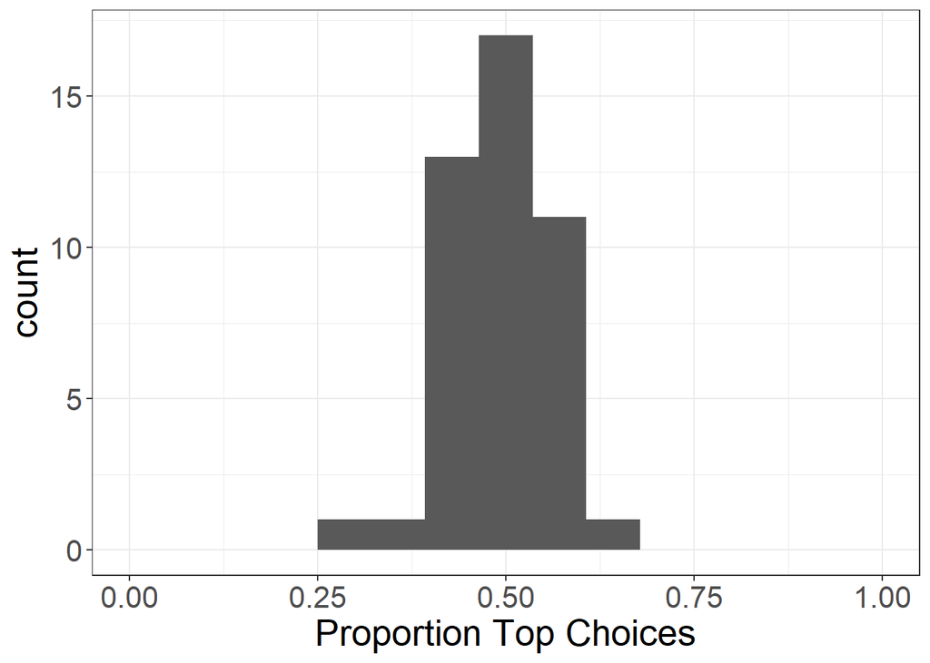

```r
#Replication sample
ggplot(data_subject, aes(x=choseTop))+
  geom_histogram(bins=15)+theme_bw()+xlab("Proportion Top Choices")+
  theme(text=element_text(size=20))+xlim(0,1)
```

```r
ggsave("plots/choiceSide.pdf",width=5.5, height=5)
```

# Correlation of Attribute index and Payne index

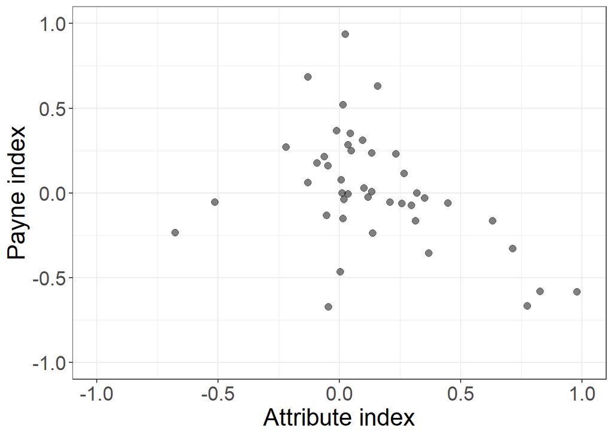

```r
#Replication sample
ggplot(data_subject, aes(x=attributeIndex, y=payneIndex)) +
    geom_point(size=2.5, alpha=.5)+
    guides(alpha=FALSE)+ theme_bw()+xlim(-1,1)+
    scale_colour_grey()+ylim(-1,1)+
    theme(text=element_text(size=20))+
    xlab("Attribute index") + ylab("Payne index")
```

```r
ggsave("plots/att_payne.pdf",width=5.7, height=5)

cor.test(data_subject$payneIndex, data_subject$attributeIndex)
```

```
##
##  Pearson's product-moment correlation
##
## data:  data_subject$payneIndex and data_subject$attributeIndex
## t = -3.0682, df = 42, p-value = 0.003763
## alternative hypothesis: true correlation is not equal to 0
## 95 percent confidence interval:
##  -0.6430829 -0.1500809
## sample estimates:
##        cor
## -0.4278959
```

# Discount rate k (logK)

Histogram of log(k)

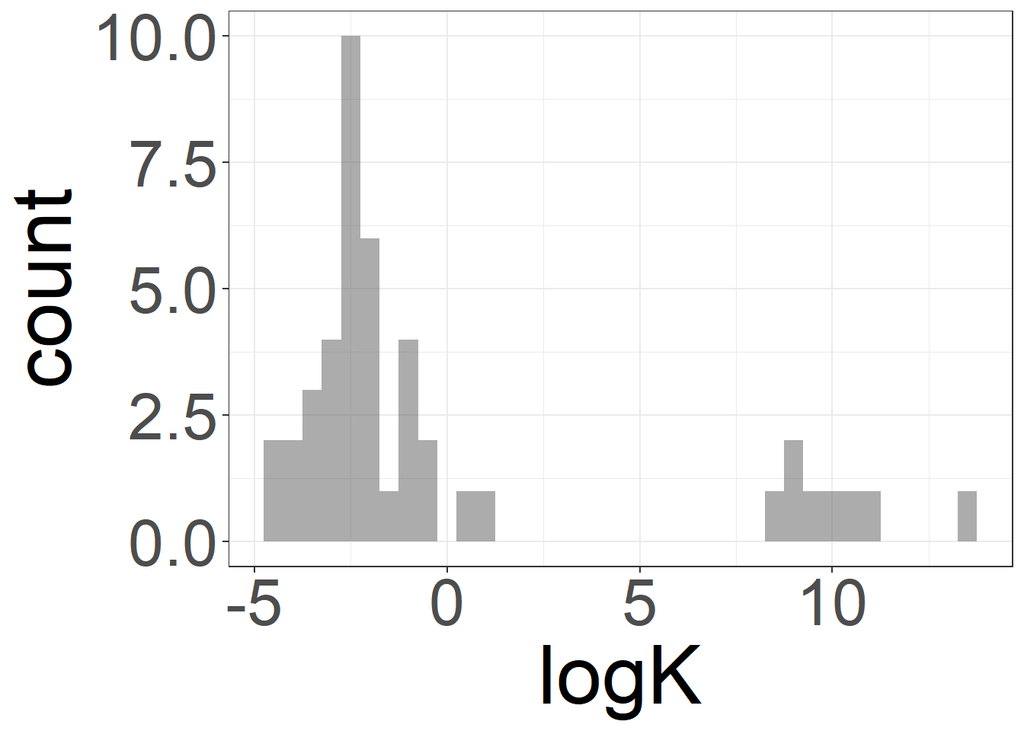

```r
ggplot(data_subject, aes(x=logK))+
  geom_histogram(binwidth=.5, alpha=.5,position="identity")+
  scale_fill_manual(values=c("palegreen","cornflowerblue"), name="") +
  theme_bw()+theme(text=element_text(size=40))
```

```r
  ggsave("plots/logk_hist.pdf", width=5.5, height=5)
```

## Correlation of Eye tracking indices and discount rate

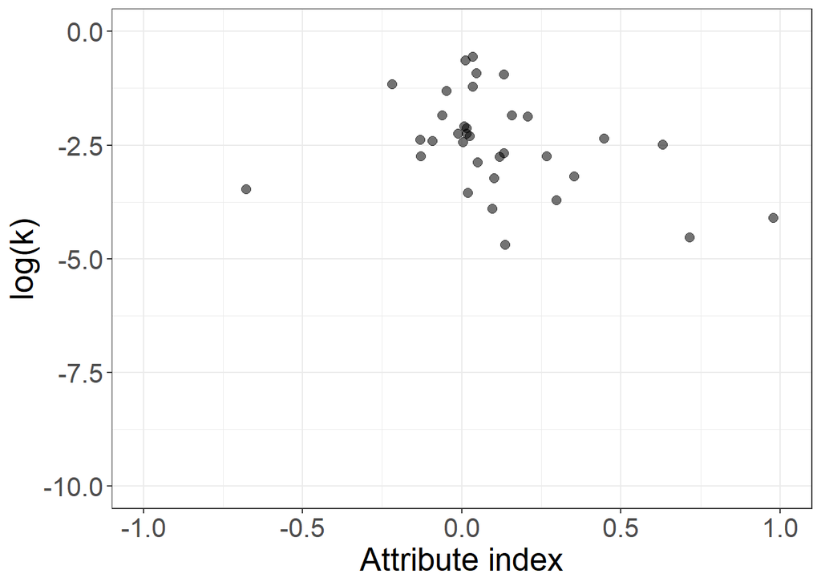

```r
#Plot correlation between attribute index and discount rate (k-val)
ggplot(data_subject, aes(x=attributeIndex, y=logK)) +
  geom_point(size=2.5, aes(alpha=.5))+
  guides(alpha=FALSE,color=FALSE, shape=FALSE)+
  theme_bw()+xlim(-1,1)+
  scale_colour_grey()+ylim(-10,0)+
  theme(text=element_text(size=20))+
  xlab("Attribute index") + ylab("log(k)")
```

```r
ggsave("plots/logk_attributeIndex.pdf",width=5.7, height=5)
cor.test(data_subject$attributeIndex, data_subject$logK)
```

```
##
##  Pearson's product-moment correlation
##
## data:  data_subject$attributeIndex and data_subject$logK
## t = 1.7197, df = 42, p-value = 0.09286
## alternative hypothesis: true correlation is not equal to 0
## 95 percent confidence interval:
##  -0.04373599  0.51420238
## sample estimates:
##       cor
## 0.2564745
```

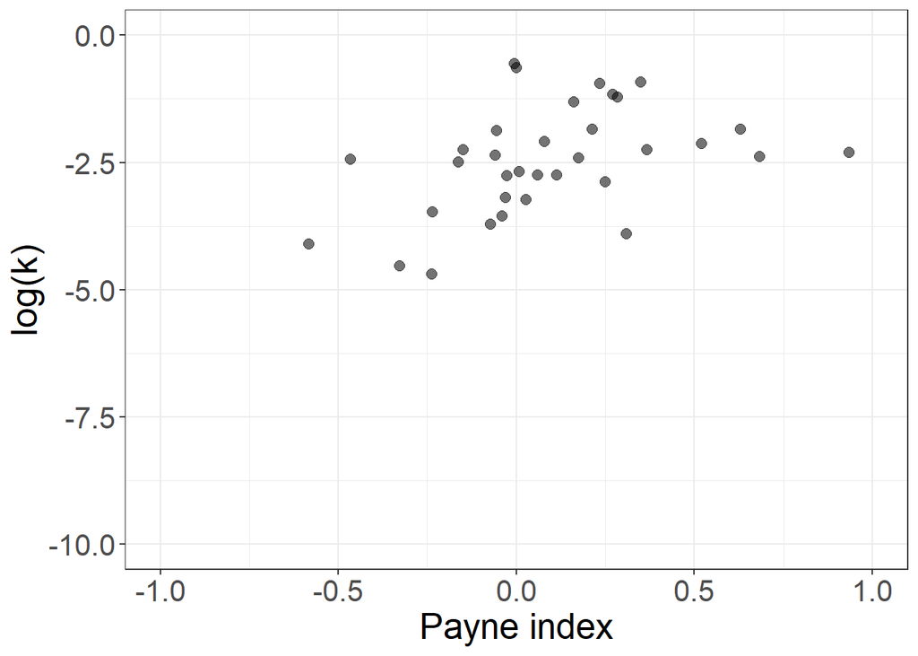

```r
#Plot correlation between Payne index and discount rate
#Replication sample
ggplot(data_subject, aes(x=payneIndex, y=logK)) +
  geom_point(size=2.5, aes(alpha=.5))+
  guides(alpha=FALSE,color=FALSE, shape=FALSE)+
  theme_bw()+xlim(-1,1)+
  scale_colour_grey()+ylim(-10,0)+
  theme(text=element_text(size=20))+
  xlab("Payne index") +
  ylab("log(k)")
```

```r
ggsave("plots/logk_payneIndex.pdf",width=5.7, height=5)
cor.test(data_subject$payneIndex,data_subject$logK)
```

```
##
##  Pearson's product-moment correlation
##
## data:  data_subject$payneIndex and data_subject$logK
## t = -1.8972, df = 42, p-value = 0.0647
## alternative hypothesis: true correlation is not equal to 0
## 95 percent confidence interval:
##  -0.53334301  0.01738259
## sample estimates:
##        cor
## -0.2809476
```

Correlation between Option Index and discount rate k

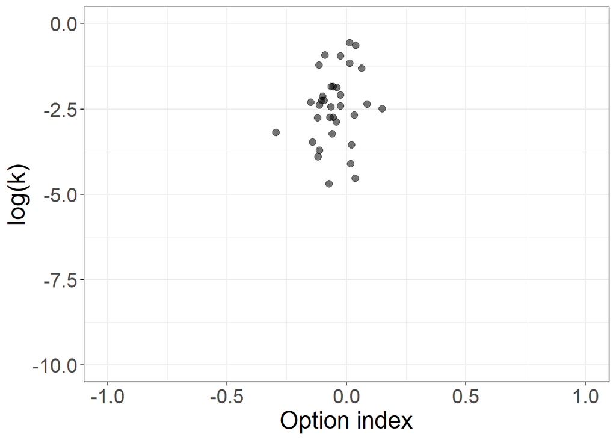

```r
# correlationPlot <- function(data, xVar, yVar, xName, yName) {
#     data$xVar <- data[, xVar]
#     data$yVar <- data[, yVar]
#
#     ggplot(data, aes(x=xVar, y=yVar)) +
#         theme_bw()+xlim(-1,1)+ylim(-10,0) +
#         scale_colour_grey(start=.1, end=.6) +
#         scale_shape_manual(values=c(16,17)) +
#         theme(text=element_text(size=20), legend.position = "none") +
#         xlab(xName) +
#         ylab(yName)
# }

ggplot(data_subject, aes(x=optionIndex, y=logK)) +
  geom_point(size=2.5, aes(alpha=.5))+
  guides(alpha=FALSE,color=FALSE, shape=FALSE)+
  theme_bw()+xlim(-1,1)+
  scale_colour_grey()+ylim(-10,0)+
  theme(text=element_text(size=20))+
  xlab("Option index") +
  ylab("log(k)")
```

```r
ggsave('plots/opt_logk.pdf',width=5.7, height=5)
cor.test(data_subject$optionIndex, data_subject$logK)
```

```
##
##  Pearson's product-moment correlation
##
## data:  data_subject$optionIndex and data_subject$logK
## t = -0.58663, df = 42, p-value = 0.5606
## alternative hypothesis: true correlation is not equal to 0
## 95 percent confidence interval:
##  -0.3769424  0.2124150
## sample estimates:
##         cor
## -0.09015045
```

# Subjective value

## Subjective value on trial-level

```r
subjectiveValue = function(data) {
    data$svLL = data$aLL / (1+ exp(data$logK) * data$tLL)
    data$svSS = data$aSS / (1+ exp(data$logK) * data$tSS)
    data$svT = data$LL_top * data$svLL +
               (1-data$LL_top) * data$svSS
    data$svB = data$LL_top * data$svSS +
               (1-data$LL_top) * data$svLL
    data$dSV_TB = data$svT - data$svB
    data$dSV_LLSS = data$svLL - data$svSS
    return(data)
}

data_trial_choice = subjectiveValue(data_trial_choice)
data_trial_choice %>%
    dplyr::select(run_id, logK, choseLL, aLL, tLL, svLL, aSS, dSV_LLSS)
```

| run_id | logK | choseLL | aLL | tLL | svLL | aSS | dSV_LLSS |
| --- | --- | --- | --- | --- | --- | --- | --- |
| 1 | -3.47850 | 1 | 4.0 | 30 | 2.077264e+00 | 3.0 | -0.9227358534 |
| 1 | -3.47850 | 1 | 4.0 | 180 | 6.103461e-01 | 1.0 | -0.3896538604 |
| 1 | -3.47850 | 1 | 4.5 | 7 | 3.700732e+00 | 2.5 | 1.2007321596 |
| 1 | -3.47850 | 0 | 4.0 | 180 | 6.103461e-01 | 2.5 | -1.8896538604 |
| 1 | -3.47850 | 0 | 4.0 | 180 | 6.103461e-01 | 2.0 | -1.3896538604 |
| 1 | -3.47850 | 1 | 5.0 | 15 | 3.418091e+00 | 3.5 | -0.0819090688 |
| 1 | -3.47850 | 1 | 4.0 | 15 | 2.734473e+00 | 2.0 | 0.7344727450 |
| 1 | -3.47850 | 0 | 4.0 | 30 | 2.077264e+00 | 0.5 | 1.5772641466 |
| 1 | -3.47850 | 1 | 5.0 | 1 | 4.850349e+00 | 4.0 | 0.8503489966 |
| 1 | -3.47850 | 0 | 5.0 | 180 | 7.629327e-01 | 1.5 | -0.7370673255 |

[output cut: 3178 more lines]

```r
data_trial_choice %>%
    dplyr::select(run_id, logK, choseTop, LL_top, aLL, tLL, svT, svB, dSV_TB)
```

| run_id | logK | choseTop | LL_top | aLL | tLL | svT | svB | dSV_TB |
| --- | --- | --- | --- | --- | --- | --- | --- | --- |
| 1 | -3.47850 | 1 | 1 | 4.0 | 30 | 2.077264e+00 | 3.000000e+00 | -0.9227358534 |
| 1 | -3.47850 | 1 | 1 | 4.0 | 180 | 6.103461e-01 | 1.000000e+00 | -0.3896538604 |
| 1 | -3.47850 | 1 | 1 | 4.5 | 7 | 3.700732e+00 | 2.500000e+00 | 1.2007321596 |
| 1 | -3.47850 | 1 | 0 | 4.0 | 180 | 2.500000e+00 | 6.103461e-01 | 1.8896538604 |
| 1 | -3.47850 | 1 | 0 | 4.0 | 180 | 2.000000e+00 | 6.103461e-01 | 1.3896538604 |
| 1 | -3.47850 | 1 | 1 | 5.0 | 15 | 3.418091e+00 | 3.500000e+00 | -0.0819090688 |
| 1 | -3.47850 | 1 | 1 | 4.0 | 15 | 2.734473e+00 | 2.000000e+00 | 0.7344727450 |
| 1 | -3.47850 | 0 | 0 | 4.0 | 30 | 5.000000e-01 | 2.077264e+00 | -1.5772641466 |
| 1 | -3.47850 | 1 | 1 | 5.0 | 1 | 4.850349e+00 | 4.000000e+00 | 0.8503489966 |
| 1 | -3.47850 | 1 | 0 | 5.0 | 180 | 1.500000e+00 | 7.629327e-01 | 0.7370673255 |

[output cut: 3178 more lines]

svLL across time

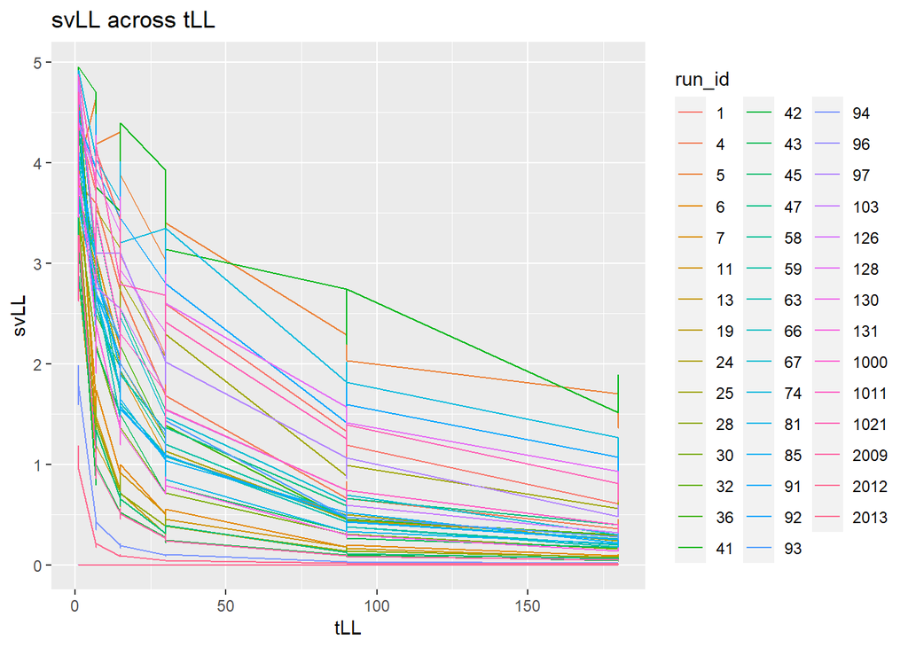

```r
data_trial_choice$run_id = factor(data_trial_choice$run_id)

ggplot(data_trial_choice, aes(x=tLL, y=svLL, color=run_id)) +
    geom_line() +
    ggtitle('svLL across tLL')
```

```r
grouped = data_trial_choice %>%
    dplyr::group_by(run_id, tLL) %>%
    dplyr::summarise(svLL = mean(svLL))
```

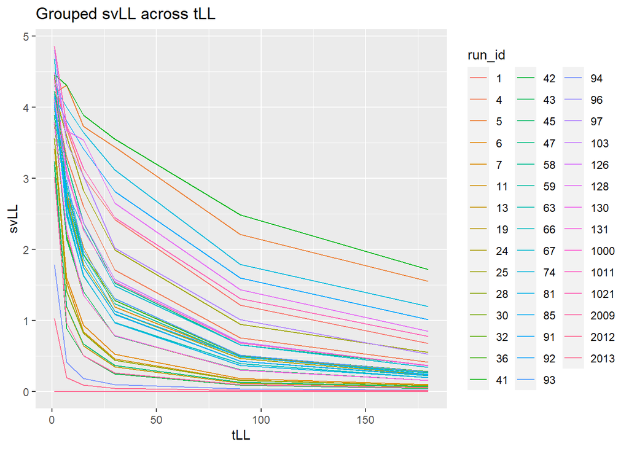

```r
ggplot(grouped, aes(x=tLL, y=svLL, color=run_id)) +
    geom_line() +
    ggtitle('Grouped svLL across tLL')
```

## Add subjective value difference (dSV) bins

### General bins

```r
nBins = 8
data_trial_choice$general_dSV_TB_bin = cut(
    data_trial_choice$dSV_TB,
    nBins,
    include.lowest=TRUE,
    labels=c(1:nBins))

data_trial_choice$general_dSV_LLSS_bin = cut(
    data_trial_choice$dSV_LLSS,
    nBins,
    include.lowest=TRUE,
    labels=c(1:nBins))

unique(data_trial_choice$general_dSV_TB_bin)
```

```
## [1] 4 6 5 3 7 2 1 8
## Levels: 1 2 3 4 5 6 7 8
```

```r
unique(data_trial_choice$general_dSV_LLSS_bin)
```

```
## [1] 4 5 6 3 7 2 1 8
## Levels: 1 2 3 4 5 6 7 8
```

### Bins on subject-level

```
data_trial_choice = data_trial_choice %>%
    mutate(dSV_TB_bin = replace(
        dSV_TB_bin,
        run_id==subjects[i],
        these_bins)
    )
```

````
#```{r}
nBins = 7
data_trial_choice$dSV_LLSS_bin = 0
subjects = unique(data_trial_choice$run_id)

for (i in 1:length(subjects)) {
    this_subject_dSV_LLSS = data_trial_choice %>%
            filter(run_id==subjects[i]) %>%
            dplyr::pull(dSV_LLSS)
    these_bins = cut(
        this_subject_dSV_LLSS,
        nBins,
        include.lowest=TRUE,
        labels=c(1:nBins))

    data_trial_choice = data_trial_choice %>%
        mutate(dSV_LLSS_bin = replace(
            dSV_TB_bin,
            run_id==subjects[i],
            these_bins)
        )
}
unique(data_trial_choice$dSV_LLSS_bin)
````

```r
grouped = data_trial_choice %>%
    dplyr::group_by(general_dSV_TB_bin) %>%
    dplyr::summarise(dSV_TB = mean(dSV_TB))


SV_bins = data_trial_choice %>%
    dplyr::group_by(run_id, general_dSV_TB_bin) %>%
    dplyr::summarise(
        choseTop=mean(choseTop),
        rt=mean(trial_duration_exact)/1000,
        count=mean(x_count)
    )
SV_bins = merge(
    SV_bins,
    grouped,
    by='general_dSV_TB_bin'
)
SV_bins
```

| general_dSV_TB_bin | run_id | choseTop | rt | count | dSV_TB |
| --- | --- | --- | --- | --- | --- |
| 1 | 1021 | 0.00000000 | 1.8880000 | 12.000000 | -3.7495717 |
| 1 | 19 | 0.66666667 | 2.0716667 | 50.733333 | -3.7495717 |
| 1 | 11 | 0.00000000 | 1.6345000 | 40.500000 | -3.7495717 |
| 1 | 67 | 0.00000000 | 1.8410000 | 27.500000 | -3.7495717 |
| 1 | 41 | 0.00000000 | 0.9800000 | 18.000000 | -3.7495717 |
| 1 | 131 | 0.00000000 | 1.8820000 | 17.000000 | -3.7495717 |
| 1 | 58 | 0.00000000 | 1.6020000 | 24.000000 | -3.7495717 |
| 1 | 13 | 0.50000000 | 1.8632500 | 49.750000 | -3.7495717 |
| 1 | 96 | 0.10000000 | 1.6282000 | 56.400000 | -3.7495717 |
| 1 | 130 | 0.63636364 | 1.7440000 | 32.727273 | -3.7495717 |

[output cut: 318 more lines]

```
## No summary function supplied, defaulting to `mean_se()`
```

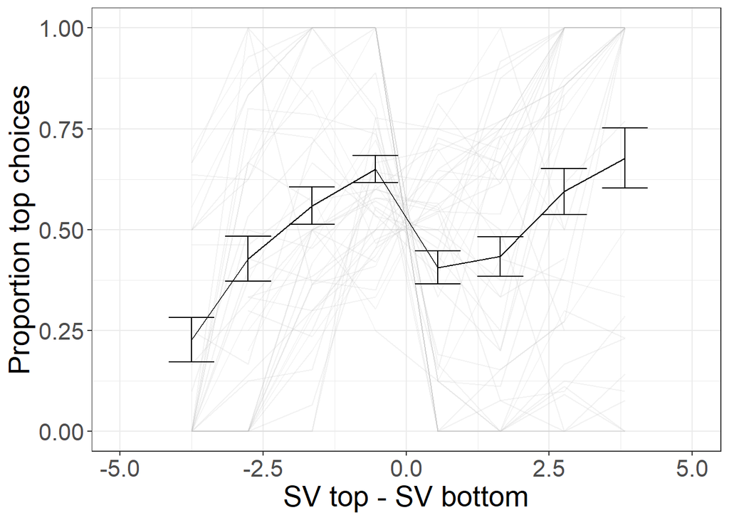

```r
#Percent choices by difference in SV
ggplot(data=SV_bins, aes(x=dSV_TB, y=choseTop)) +
    theme_bw() +
    geom_line(color='grey',alpha=.2, aes(group=as.numeric(run_id))) +
    xlim(-5,5) +
    geom_line(stat="summary", fun.y="mean", size=.5)+
    stat_summary(fun.data=mean_se, geom="errorbar", width=.8)+
    xlab("SV top - SV bottom")+ylab("Proportion top choices")+
    theme(text=element_text(size=20))+ylim(0,1)
```

```r
ggsave("plots/SV_TB.pdf", width=5.5, height=5)
```

```
## No summary function supplied, defaulting to `mean_se()`
```

```
## No summary function supplied, defaulting to `mean_se()`
```

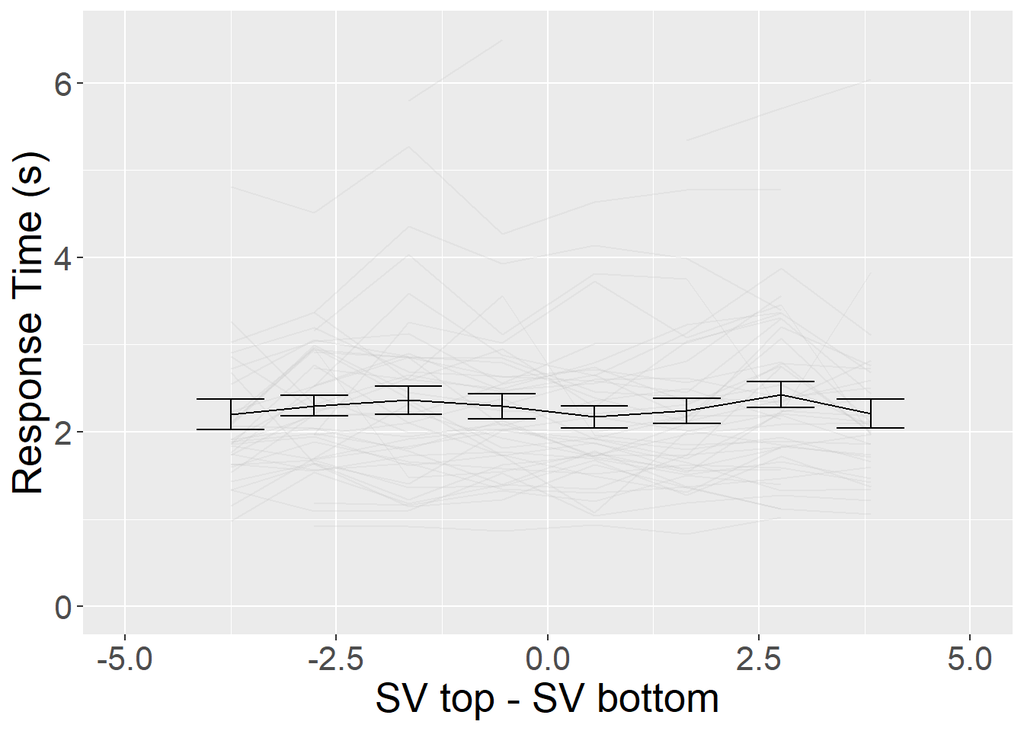

```r
#RT by difference in SV

#Replication sample (T/B)
ggplot(data=SV_bins, aes(x=dSV_TB, y=rt)) +
    geom_line(color='grey',alpha=.2, aes(group=as.numeric(run_id))) +
    xlim(-5,5) +
    geom_line(stat="summary", fun.y="mean", size=.5) +
    stat_summary(fun.data=mean_se, geom="errorbar", width=.8) +
    xlab("SV top - SV bottom") +
    ylab("Response Time (s)") +
    theme(text=element_text(size=20))+ylim(0,6.5)
```

```r
ggsave("plots/SV_RT.pdf",width=5.5, height=5)
```

```
## No summary function supplied, defaulting to `mean_se()`
```

```
## No summary function supplied, defaulting to `mean_se()`
```

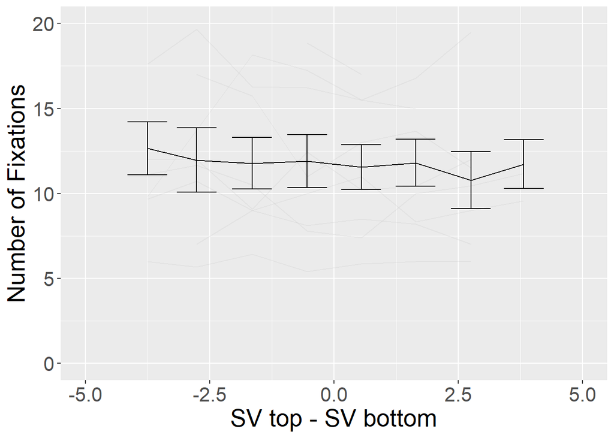

```r
ggplot(data=SV_bins, aes(x=dSV_TB, y=count)) +
    geom_line(color='grey',alpha=.2, aes(group=as.numeric(run_id))) +
    xlim(-5,5) +
    geom_line(stat="summary", fun.y="mean", size=.5) +
    stat_summary(fun.data=mean_se, geom="errorbar", width=.8) +
    xlab("SV top - SV bottom") +
    ylab("Number of Fixations") +
    theme(text=element_text(size=20))+ylim(0,20)
```

```r
ggsave("plots/SV_Count.pdf",width=5.5, height=5)
```

```
## No summary function supplied, defaulting to `mean_se()`
```

# Eye Tracking Bins

Eye tracking bins with average proportion of looking top for each subject over trials when they chose the top option (binsT) or the bottom option (binsB).

## Calculate bins

```r
ET_bins = function(data, nBins) {
    data$bin = 0
    subjects = unique(data$run_id)
    for (i in 1:length(subjects)) {
        maxChoices = data %>%
                filter(run_id == subjects[i]) %>%
                dplyr::select(withinTaskIndex) %>%
                max

        for (j in 1:maxChoices) {
            nData = c(1:nrow(
                data %>% filter(run_id==subjects[i] & withinTaskIndex==j))
                )
            theseBins = cut(nData, nBins, include.lowest=TRUE, labels=c(1:nBins))

            data = data %>%
                mutate(bin = replace(
                    bin,
                    (run_id==subjects[i] & withinTaskIndex==j),
                    theseBins)
                )
        }
    }
    return(data)
}

data_et_choice = ET_bins(data_et_choice, 2)
data_et_choice %>%
    filter(run_id==1) %>%
    dplyr::select(x, y, bin)
```

| x | y | bin |
| --- | --- | --- |
| 0.6048332 | 0.4258297 | 1 |
| 0.4055297 | 0.4082066 | 1 |
| 0.6227401 | 0.3879738 | 1 |
| 0.6276048 | 0.4291640 | 1 |
| 0.4986325 | 0.3005936 | 1 |
| 0.5927368 | 0.4150149 | 2 |
| 0.3966585 | 0.2224686 | 2 |
| 0.4583228 | 0.3175678 | 2 |
| 0.5271275 | 0.3369067 | 2 |
| 0.4767176 | 0.4856408 | 1 |

[output cut: 268 more lines]

```r
ET_bins_choseTop <- data_et_choice %>%
    filter(choseTop == 1 & !is.na(aoi)) %>%
    ET_bins(3) %>%
    dplyr::select(run_id, withinTaskIndex, bin, lookTopAOI, choseTop) %>%
    dplyr::group_by(run_id, choseTop, bin) %>%
    dplyr::summarise(lookTopAOI=mean(lookTopAOI)) %>%
    spread(bin, lookTopAOI)
ET_bins_choseBottom <- data_et_choice %>%
    filter(choseTop == 0 & !is.na(aoi)) %>%
    ET_bins(3) %>%
    dplyr::select(run_id, withinTaskIndex, bin, lookTopAOI, choseTop) %>%
    dplyr::group_by(run_id, choseTop, bin) %>%
    dplyr::summarise(lookTopAOI=mean(lookTopAOI)) %>%
    spread(bin, lookTopAOI)
ET_bins_choseTB_long <- data_et_choice %>%
    filter(!is.na(aoi)) %>%
    ET_bins(3) %>%
    dplyr::select(run_id, withinTaskIndex, bin, lookTopAOI, choseTop) %>%
    dplyr::group_by(run_id, choseTop, bin) %>%
    dplyr::summarise(lookTopAOI=mean(lookTopAOI))
ET_bins_choseTB_long
```

| run_id | choseTop | bin | lookTopAOI |
| --- | --- | --- | --- |
| 1 | 0 | 1 | 0.161290323 |
| 1 | 0 | 2 | 0.217391304 |
| 1 | 0 | 3 | 0.208333333 |
| 1 | 1 | 1 | 0.175675676 |
| 1 | 1 | 2 | 0.174603175 |
| 1 | 1 | 3 | 0.126984127 |
| 4 | 0 | 1 | 0.323863636 |
| 4 | 0 | 2 | 0.365853659 |
| 4 | 0 | 3 | 0.439169139 |
| 4 | 1 | 1 | 0.368020305 |

[output cut: 254 more lines]

```r
ET_bins_choseTB_wide<-rbind(ET_bins_choseTop, ET_bins_choseBottom)
ET_bins_choseTB_wide
```

| run_id | choseTop | 1 | 2 | 3 |
| --- | --- | --- | --- | --- |
| 1 | 1 | 0.17567568 | 0.17460317 | 0.126984127 |
| 4 | 1 | 0.36802030 | 0.33423913 | 0.318421053 |
| 5 | 1 | 0.43440233 | 0.40063091 | 0.442771084 |
| 6 | 1 | 0.29065744 | 0.26335878 | 0.295620438 |
| 7 | 1 | 0.48841202 | 0.46935201 | 0.475736568 |
| 11 | 1 | 0.38202247 | 0.42184874 | 0.390804598 |
| 13 | 1 | 0.19746121 | 0.17391304 | 0.212553495 |
| 19 | 1 | 0.45768566 | 0.48381295 | 0.423550088 |
| 24 | 1 | 0.48633094 | 0.56053812 | 0.527859238 |
| 25 | 1 | 0.25931677 | 0.27243067 | 0.315372425 |

[output cut: 78 more lines]

## Plot look top AOI across time bins

[figure not shown]

```r
# https://stackoverflow.com/a/45614547
GeomSplitViolin <- ggproto("GeomSplitViolin", GeomViolin, draw_group = function(self, data, ..., draw_quantiles = NULL){
  data <- transform(data, xminv = x - violinwidth * (x - xmin), xmaxv = x + violinwidth * (xmax - x))
  grp <- data[1,'group']
  newdata <- plyr::arrange(transform(data, x = if(grp%%2==1) xminv else xmaxv), if(grp%%2==1) y else -y)
  newdata <- rbind(newdata[1, ], newdata, newdata[nrow(newdata), ], newdata[1, ])
  newdata[c(1,nrow(newdata)-1,nrow(newdata)), 'x'] <- round(newdata[1, 'x'])
  if (length(draw_quantiles) > 0 & !scales::zero_range(range(data$y))) {
    stopifnot(all(draw_quantiles >= 0), all(draw_quantiles <=
                                              1))
    quantiles <- ggplot2:::create_quantile_segment_frame(data, draw_quantiles)
    aesthetics <- data[rep(1, nrow(quantiles)), setdiff(names(data), c("x", "y")), drop = FALSE]
    aesthetics$alpha <- rep(1, nrow(quantiles))
    both <- cbind(quantiles, aesthetics)
    quantile_grob <- GeomPath$draw_panel(both, ...)
    ggplot2:::ggname("geom_split_violin", grid::grobTree(GeomPolygon$draw_panel(newdata, ...), quantile_grob))
  }
  else {
    ggplot2:::ggname("geom_split_violin", GeomPolygon$draw_panel(newdata, ...))
  }
})

geom_split_violin <- function (mapping = NULL, data = NULL, stat = "ydensity", position = "identity", ..., draw_quantiles = NULL, trim = TRUE, scale = "area", na.rm = FALSE, show.legend = NA, inherit.aes = TRUE) {
  layer(data = data, mapping = mapping, stat = stat, geom = GeomSplitViolin, position = position, show.legend = show.legend, inherit.aes = inherit.aes, params = list(trim = trim, scale = scale, draw_quantiles = draw_quantiles, na.rm = na.rm, ...))
}

ET_bins_choseTB_long$choseTop = as.factor(ET_bins_choseTB_long$choseTop)
ET_bins_choseTB_long$bin = as.factor(ET_bins_choseTB_long$bin)

#Violin plot of time bins
ggplot(ET_bins_choseTB_long, aes(x=bin, y=lookTopAOI, fill=choseTop)) +
      geom_split_violin(alpha=.7, size=1, position="dodge") +
      stat_summary(
          fun=mean, geom="point",
          shape=45,size=10,
          position=position_dodge(.9),
          aes(color=choseTop)) +
      scale_colour_manual(
          values=c(1, 2),
          name="",
          labels=c("Chose top", "Chose bottom")) +
      scale_fill_grey(
          start=.3, end=.7, name="",
          labels=c("Chose top", "Chose bottom")) +
      xlab("Time bins") +
      ylab("Proportion looking top") +
      theme_bw() +
      theme(text=element_text(size=20),
      legend.position="bottom")
```

```r
      # If significant
#      geom_text(x=1, y=1.01, label="") +
#      annotate("segment",x=0.7, xend=1.3, y=1, yend=1) +
#      geom_text(x=2, y=1.01, label="") +
#      annotate("segment",x=1.7, xend=2.3, y=1, yend=1) +
#      geom_text(x=3, y=1.01, label="") +
#      annotate("segment",x=2.7, xend=3.3, y=1, yend=1) +


ggsave("plots/ET_TB.pdf",width=5.5, height=5)
```

## Predict lookTopAOI by choseTop

```r
ET_bins_choseTB_long$choseTop = as.factor(ET_bins_choseTB_long$choseTop)

for (i in 1:length(unique(ET_bins_choseTB_long$bin))) {
    this_bin = ET_bins_choseTB_long %>%
        filter(bin==i)
    print(t.test(lookTopAOI ~ choseTop, data=this_bin, paired=TRUE))

}
```

```
##
##  Paired t-test
##
## data:  lookTopAOI by choseTop
## t = -1.6399, df = 43, p-value = 0.1083
## alternative hypothesis: true difference in means is not equal to 0
## 95 percent confidence interval:
##  -0.037018966  0.003814105
## sample estimates:
## mean of the differences
##             -0.01660243
##
##
##  Paired t-test
##
## data:  lookTopAOI by choseTop
## t = -2.2289, df = 43, p-value = 0.0311
## alternative hypothesis: true difference in means is not equal to 0
## 95 percent confidence interval:
##  -0.035267076 -0.001762612
## sample estimates:
## mean of the differences
##             -0.01851484
##
##
##  Paired t-test
##
## data:  lookTopAOI by choseTop
## t = -2.3155, df = 43, p-value = 0.02542
## alternative hypothesis: true difference in means is not equal to 0
## 95 percent confidence interval:
##  -0.038308526 -0.002642055
## sample estimates:
## mean of the differences
##             -0.02047529
```

```r
#cohen.d(as.numeric(choseT[[3]]),as.numeric(choseB[[3]]),pooled=TRUE,paired=TRUE)
```

## Proportion of top choice based on the last fixation being to the top

```r
add_lastFixTop = function(data_trial, data_et) {
    grouped = data_et %>%
        dplyr::group_by(run_id, trial_index) %>%
        dplyr::summarise(t_task = max(t_task))
    grouped = merge(
        grouped,
        data_et %>%
              dplyr::select(run_id, trial_index, t_task, aoi),
        by=c('run_id', 'trial_index', 't_task')
        )

    grouped = grouped %>%
        mutate(lastFixTop = as.numeric(aoi %in% c('TL', 'TR'))) %>%
        dplyr::select(run_id, trial_index, lastFixTop)

    if ('lastFixTop' %in% names(data_trial)) {
        data_trial = data_trial %>% select(!lastFixTop)}
    data_trial = merge(
        data_trial, grouped, by=c('run_id', 'trial_index'))
    return(data_trial)
}

data_trial_choice = add_lastFixTop(data_trial_choice, data_et_choice)
data_trial_choice %>%
    dplyr::select(run_id, trial_index, choseTop, lastFixTop)
```

| run_id | trial_index | choseTop | lastFixTop |
| --- | --- | --- | --- |
| 1 | 145 | 1 | 0 |
| 1 | 160 | 1 | 0 |
| 1 | 163 | 1 | 0 |
| 1 | 196 | 1 | 0 |
| 1 | 199 | 1 | 0 |
| 1 | 211 | 1 | 0 |
| 1 | 220 | 1 | 1 |
| 1 | 232 | 0 | 0 |
| 1 | 235 | 1 | 0 |
| 1 | 241 | 1 | 0 |

[output cut: 3178 more lines]

```r
lookT_lastFix <- data_trial_choice %>%
    filter(lastFixTop == 1) %>%
    dplyr::select(run_id, withinTaskIndex, choseTop) %>%
    dplyr::group_by(run_id, withinTaskIndex) %>%
    dplyr::summarise(choseTop=mean(choseTop)) %>%
    dplyr::group_by(run_id) %>%
    dplyr::summarise(choseTop=mean(choseTop))
lookB_lastFix <- data_trial_choice %>%
    filter(lastFixTop == 0) %>%
    dplyr::select(run_id, withinTaskIndex, choseTop) %>%
    dplyr::group_by(run_id, withinTaskIndex) %>%
    dplyr::summarise(choseTop=mean(choseTop)) %>%
    dplyr::group_by(run_id) %>%
    dplyr::summarise(choseTop=mean(choseTop))
lookTB_lastFix_long <- data_trial_choice %>%
    dplyr::select(run_id, withinTaskIndex, lastFixTop, choseTop) %>%
    dplyr::group_by(run_id, lastFixTop, withinTaskIndex) %>%
    dplyr::summarise(choseTop=mean(choseTop)) %>%
    dplyr::group_by(run_id, lastFixTop) %>%
    dplyr::summarise(choseTop=mean(choseTop))
lookTB_lastFix_long
```

| run_id | lastFixTop | choseTop |
| --- | --- | --- |
| 1 | 0 | 0.6666667 |
| 1 | 1 | 0.8000000 |
| 4 | 0 | 0.5090909 |
| 4 | 1 | 0.5714286 |
| 5 | 0 | 0.4222222 |
| 5 | 1 | 0.5142857 |
| 6 | 0 | 0.4615385 |
| 6 | 1 | 0.3333333 |
| 7 | 0 | 0.3863636 |
| 7 | 1 | 0.5000000 |

[output cut: 77 more lines]

```r
subjects_only_look_top = lookTB_lastFix_long %>%
    dplyr::group_by(run_id) %>%
    dplyr::summarise(n = n()) %>%
    filter(n<2) %>%
    dplyr::pull(run_id)
lookTB_lastFix_long = lookTB_lastFix_long %>%
    filter(!(run_id %in% subjects_only_look_top))
lookTB_lastFix_long
```

| run_id | lastFixTop | choseTop |
| --- | --- | --- |
| 1 | 0 | 0.6666667 |
| 1 | 1 | 0.8000000 |
| 4 | 0 | 0.5090909 |
| 4 | 1 | 0.5714286 |
| 5 | 0 | 0.4222222 |
| 5 | 1 | 0.5142857 |
| 6 | 0 | 0.4615385 |
| 6 | 1 | 0.3333333 |
| 7 | 0 | 0.3863636 |
| 7 | 1 | 0.5000000 |

[output cut: 76 more lines]

```r
#Violin plot last fixation location

lookTB_lastFix_long$lastFixTop = as.factor(lookTB_lastFix_long$lastFixTop)
t.test(choseTop ~ lastFixTop, data=lookTB_lastFix_long, paired=TRUE)
```

```
##
##  Paired t-test
##
## data:  choseTop by lastFixTop
## t = -5.6891, df = 42, p-value = 1.111e-06
## alternative hypothesis: true difference in means is not equal to 0
## 95 percent confidence interval:
##  -0.2580856 -0.1229290
## sample estimates:
## mean of the differences
##              -0.1905073
```

```r
lookTB_lastFix_long %>%
    filter(lastFixTop == 1) %>%
    dplyr::select(choseTop)
```

| run_id | choseTop |
| --- | --- |
| 1 | 0.8000000 |
| 4 | 0.5714286 |
| 5 | 0.5142857 |
| 6 | 0.3333333 |
| 7 | 0.5000000 |
| 11 | 0.6250000 |
| 13 | 0.5666667 |
| 19 | 0.7500000 |
| 24 | 0.5510204 |
| 25 | 0.7619048 |

[output cut: 33 more lines]

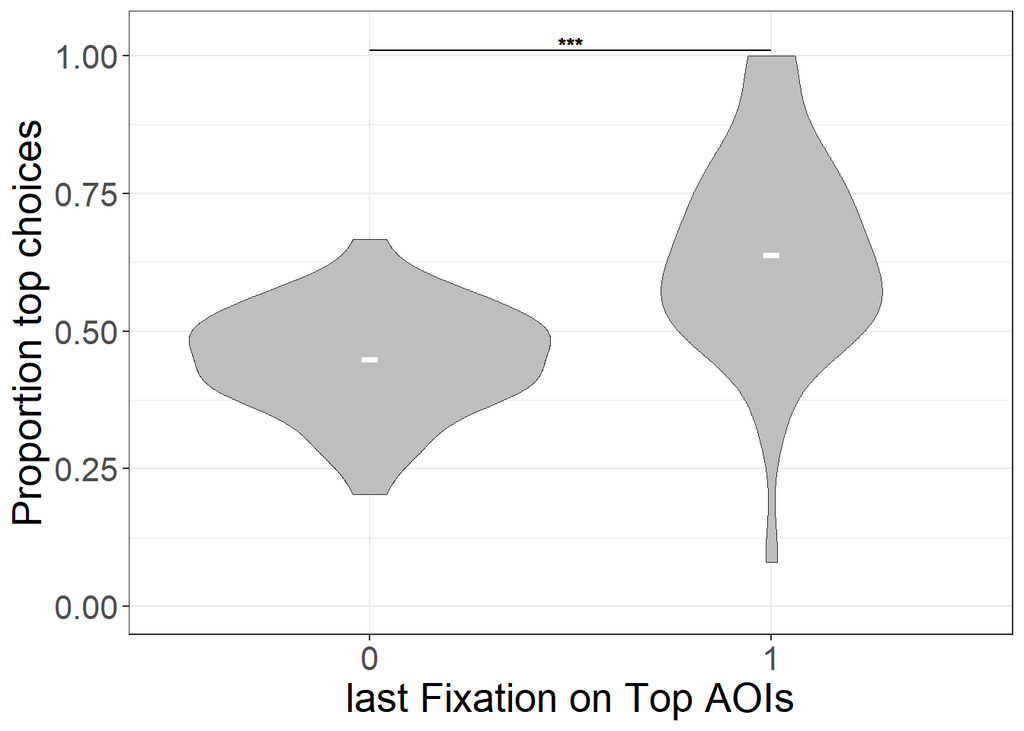

```r
ggplot(lookTB_lastFix_long, aes(x=lastFixTop, y=choseTop)) +
    geom_violin(fill="gray", size=0) +
    stat_summary(fun=mean,geom="point",shape=45,size=10, color="white") +
    geom_text(x=1.5, y=1.02, label="***") +
    annotate("segment",x=1, xend=2, y=1.01, yend=1.01) +
    theme_bw()+ylim(0,1.03)+xlab("") +
    ylab("Proportion top choices") +
    xlab("last Fixation on Top AOIs") +
    theme(text=element_text(size=20))
```

```r
ggsave("plots/ET_look_TB.pdf",width=5.5, height=5)
```

# Error Analyis

Error trials are those that are not predicted based on the subjective values, which themselves are based on individual’s fitted k value

## Find Error trials

```r
identify_error_trials = function(data) {
    data$predictLL = as.integer(data$svLL > data$svSS)
    data$errorTrial = as.integer((data$choseLL != data$predictLL))
    data$patientError = as.integer((data$choseLL & !data$predictLL))
    data$impatientError = as.integer((!data$choseLL & data$predictLL))
    return(data)
}

data_trial_choice = identify_error_trials(data_trial_choice)

data_trial_choice %>%
    dplyr::select(svLL, svSS, predictLL, choseLL,
                  errorTrial, patientError, impatientError,
                  )
```

| svLL | svSS | predictLL | choseLL | errorTrial | patientError | impatientError |
| --- | --- | --- | --- | --- | --- | --- |
| 2.077264e+00 | 3.0 | 0 | 1 | 1 | 1 | 0 |
| 6.103461e-01 | 1.0 | 0 | 1 | 1 | 1 | 0 |
| 3.700732e+00 | 2.5 | 1 | 1 | 0 | 0 | 0 |
| 6.103461e-01 | 2.5 | 0 | 0 | 0 | 0 | 0 |
| 6.103461e-01 | 2.0 | 0 | 0 | 0 | 0 | 0 |
| 3.418091e+00 | 3.5 | 0 | 1 | 1 | 1 | 0 |
| 2.734473e+00 | 2.0 | 1 | 1 | 0 | 0 | 0 |
| 2.077264e+00 | 0.5 | 1 | 0 | 1 | 0 | 1 |
| 4.850349e+00 | 4.0 | 1 | 1 | 0 | 0 | 0 |
| 7.629327e-01 | 1.5 | 0 | 0 | 0 | 0 | 0 |

[output cut: 3178 more lines]

```r
data_trial_choice %>%
    dplyr::select(run_id, svLL, svSS, predictLL, choseLL,
                  errorTrial, patientError, impatientError,
                  ) %>%
    filter(run_id==61)
```

| run_id | svLL | svSS | predictLL | choseLL | errorTrial | patientError | impatientError |
| --- | --- | --- | --- | --- | --- | --- | --- |

```r
data_trial_choice %>%
    dplyr::group_by(run_id) %>%
    dplyr::summarise(choseLL = mean(choseLL), errorTrial=sum(errorTrial))
```

|  | run_id | choseLL | errorTrial |
| --- | --- | --- | --- |
| 1 | 1 | 0.4411765 | 11 |
| 2 | 4 | 0.3421053 | 23 |
| 3 | 5 | 0.4625000 | 49 |
| 4 | 6 | 0.3375000 | 26 |
| 5 | 7 | 0.4375000 | 30 |
| 6 | 11 | 0.1750000 | 14 |
| 7 | 13 | 0.3544304 | 28 |
| 8 | 19 | 0.3750000 | 30 |
| 9 | 24 | 0.2625000 | 18 |
| 10 | 25 | 0.4177215 | 31 |

[output cut: 34 more lines]

## Find Correct trial for each Error trial

```r
matchTrials = function(data) {
    data$matched_trial=0
    for (i in 1:nrow(data)) {
        if (data[i, ]$errorTrial) {
            if (data[i, ]$impatientError) {
                correctTrials = data %>%
                    filter(
                        run_id==data[i, ]$run_id &
                        !errorTrial & choseLL) %>%
                    dplyr::select(run_id, withinTaskIndex, dSV_LLSS)

            }
            if (data[i, ]$patientError) {
                correctTrials = data %>%
                    filter(
                        run_id==data[i, ]$run_id &
                        !errorTrial & !choseLL) %>%
                    dplyr::select(run_id, withinTaskIndex, dSV_LLSS)
            }
        # If it is an error trial

            if (nrow(correctTrials) > 0) {
                correctTrials$dSV_difference =
                    abs(correctTrials$dSV_LLSS - data[i, ]$dSV_LLSS)

                matched_trials = correctTrials %>%
                    filter(dSV_difference ==
                                min(correctTrials$dSV_difference)) %>%
                    dplyr::pull(withinTaskIndex)

                data[i, ]$matched_trial = matched_trials[1]

                if (length(matched_trials)>1) {
                    already_matched = data %>%
                        filter(run_id==data[i, ]$run_id) %>%
                        dplyr::pull(matched_trial)

                    for (j in 1:length(matched_trials)) {
                        if (!(matched_trials[j] %in% already_matched)) {
                            data[i, ]$matched_trial = matched_trials[j]
                        }
                    }
                }
            }
        }
    }
    return(data)
}
data_trial_choice = matchTrials(data_trial_choice)
```

## Reaction time and option INdexRT

### LL>SS: LL was predicted.

Do subjects behave differently when they correctly choose LL (as expected) than when they unexpectedly chose SS instead?

```r
subjects_LLcorrect = data_trial_choice %>%
    filter(
              (
                  (predictLL & !errorTrial) |
                  (predictLL & errorTrial)
              )
          ) %>%
    dplyr::group_by(run_id) %>%
    dplyr::summarise(n_unique_matched = length(unique(matched_trial))) %>%
    filter(n_unique_matched>2) %>%
    dplyr::pull(run_id)
subjects_LLcorrect
```

```
##  [1] 1    4    5    7    24   25   30   36   41   43   47   58   59   63   67
## [16] 74   81   85   91   92   93   97   103  128  131  1011 1021
## 44 Levels: 1 4 5 6 7 11 13 19 24 25 28 30 32 36 41 42 43 45 47 58 59 63 ... 2013
```

```r
length(subjects_LLcorrect)
```

```
## [1] 27
```

```r
grouped_LLcorrect =  data_trial_choice %>%
    filter(
              (
                  (predictLL & !errorTrial) |
                  (predictLL & errorTrial)
              ) &
              (run_id %in% subjects_LLcorrect)
          ) %>%
    dplyr::group_by(run_id, errorTrial) %>%
    dplyr::summarise(n = n(),
              rt = mean(trial_duration_exact),
              optionIndex = mean(optionIndex),
              attributeIndex = mean(attributeIndex),
              payneIndex = mean(payneIndex))
grouped_LLcorrect$errorTrial = factor(grouped_LLcorrect$errorTrial)
grouped_LLcorrect
```

| run_id | errorTrial | n | rt | optionIndex | attributeIndex | payneIndex |
| --- | --- | --- | --- | --- | --- | --- |
| 1 | 0 | 8 | 4386.8750 | -0.37500000 | -0.37500000 | -0.25000000 |
| 1 | 1 | 4 | 3885.5000 | 0.00000000 | -0.50000000 | 0.00000000 |
| 4 | 0 | 13 | 2534.3846 | -0.87573964 | 0.23753763 | 0.38461538 |
| 4 | 1 | 10 | 2349.9000 | 0.63385695 | 0.01646390 | 0.10000000 |
| 5 | 0 | 20 | 1327.4000 | -0.76751166 | 0.61262821 | -0.22666667 |
| 5 | 1 | 32 | 1223.8750 | 0.65145323 | 0.84114661 | -0.49375000 |
| 7 | 0 | 14 | 2770.0000 | -0.34814562 | -0.19340999 | 0.02908163 |
| 7 | 1 | 9 | 2962.7778 | 0.28728920 | -0.11184874 | 0.15993266 |
| 24 | 0 | 10 | 2157.7000 | -1.00000000 | -0.04581874 | 0.95000000 |
| 24 | 1 | 7 | 2145.2857 | 0.71428571 | 0.16974698 | 0.85714286 |

[output cut: 44 more lines]

```r
criteria = c('rt', 'optionIndex', 'attributeIndex', 'payneIndex')
lapply(criteria, function(x)
     t.test(as.formula(paste(x,"errorTrial",sep="~")),
            data=grouped_LLcorrect,
           paired=TRUE, na.action=na.pass)
)
```

```
## [[1]]
##
##  Paired t-test
##
## data:  rt by errorTrial
## t = 2.416, df = 26, p-value = 0.02302
## alternative hypothesis: true difference in means is not equal to 0
## 95 percent confidence interval:
##   25.35352 314.51709
## sample estimates:
## mean of the differences
##                169.9353
##
##
## [[2]]
##
##  Paired t-test
##
## data:  optionIndex by errorTrial
## t = -2.7937, df = 26, p-value = 0.009652
## alternative hypothesis: true difference in means is not equal to 0
## 95 percent confidence interval:
##  -0.9209591 -0.1401885
## sample estimates:
## mean of the differences
##              -0.5305738
##
##
## [[3]]
##
##  Paired t-test
##
## data:  attributeIndex by errorTrial
## t = -1.2187, df = 26, p-value = 0.2339
## alternative hypothesis: true difference in means is not equal to 0
## 95 percent confidence interval:
##  -0.21083913  0.05388776
## sample estimates:
## mean of the differences
##             -0.07847569
##
##
## [[4]]
##
##  Paired t-test
##
## data:  payneIndex by errorTrial
## t = 0.49357, df = 26, p-value = 0.6258
## alternative hypothesis: true difference in means is not equal to 0
## 95 percent confidence interval:
##  -0.0932548  0.1521907
## sample estimates:
## mean of the differences
##              0.02946795
```

```r
grouped_LLcorrect %>%
    dplyr::group_by(errorTrial) %>%
    dplyr::summarise(n = sum(n),
              rt = mean(rt),
              optionIndex = mean(optionIndex),
              attributeIndex = mean(attributeIndex),
              payneIndex = mean(payneIndex))
```

|  | errorTrial | n | rt | optionIndex | attributeIndex | payneIndex |
| --- | --- | --- | --- | --- | --- | --- |
| 1 | 0 | 339 | 2312.663 | -0.3177572 | 0.1616384 | 0.06617094 |
| 2 | 1 | 304 | 2142.727 | 0.2128166 | 0.2401140 | 0.03670299 |

### SS>LL: SS was predicted.

Do subjects behave differently when they correctly choose SS (as expected) than when they unexpectedly chose LL instead?

```r
subjects_SScorrect = data_trial_choice %>%
    filter(
              (
                  (!predictLL & !errorTrial) |
                  (!predictLL & errorTrial)
              )
          ) %>%
    dplyr::group_by(run_id) %>%
    dplyr::summarise(n_unique_matched = length(unique(matched_trial))) %>%
    filter(n_unique_matched>2) %>%
    dplyr::pull(run_id)
subjects_SScorrect
```

```
##  [1] 1    4    5    6    7    11   13   19   24   25   28   30   32   36   41
## [16] 42   43   45   47   58   59   63   66   67   74   81   85   91   92   93
## [31] 94   96   97   103  126  128  130  131  1000 1011 1021 2009 2012 2013
## 44 Levels: 1 4 5 6 7 11 13 19 24 25 28 30 32 36 41 42 43 45 47 58 59 63 ... 2013
```

```r
length(subjects_SScorrect)
```

```
## [1] 44
```

```r
grouped_SScorrect =  data_trial_choice %>%
    filter(
              (
                  (!predictLL & !errorTrial) |
                  (!predictLL & errorTrial)
              ) &
              (run_id %in% subjects_LLcorrect)
          ) %>%
    dplyr::group_by(run_id, errorTrial) %>%
    dplyr::summarise(n = n(),
              rt = mean(trial_duration_exact),
              optionIndex = mean(optionIndex),
              attributeIndex = mean(attributeIndex),
              payneIndex = mean(payneIndex))
grouped_SScorrect$errorTrial = factor(grouped_SScorrect$errorTrial)
grouped_SScorrect
```

| run_id | errorTrial | n | rt | optionIndex | attributeIndex | payneIndex |
| --- | --- | --- | --- | --- | --- | --- |
| 1 | 0 | 15 | 3777.933 | 0.01333333 | -0.866666667 | -0.333333333 |
| 1 | 1 | 7 | 3956.714 | -0.28571429 | -0.714285714 | -0.142857143 |
| 4 | 0 | 40 | 2771.600 | 0.30999262 | 0.030410336 | 0.249166667 |
| 4 | 1 | 13 | 2723.154 | -0.80889813 | -0.051949852 | 0.228205128 |
| 5 | 0 | 11 | 1331.636 | 0.91562686 | 0.686368327 | -0.136363636 |
| 5 | 1 | 17 | 1273.588 | -0.74071450 | 0.619208444 | -0.254901961 |
| 7 | 0 | 36 | 3207.972 | 0.23989635 | -0.050576531 | 0.183862434 |
| 7 | 1 | 21 | 3028.190 | -0.39688731 | -0.088256717 | 0.264852608 |
| 24 | 0 | 52 | 2863.558 | 0.07692308 | 0.011465326 | 0.930036630 |
| 24 | 1 | 11 | 2646.455 | -1.00000000 | 0.066358075 | 1.000000000 |

[output cut: 44 more lines]

```r
criteria = c('rt', 'optionIndex', 'attributeIndex', 'payneIndex')
lapply(criteria, function(x)
     t.test(as.formula(paste(x,"errorTrial",sep="~")),
            data=grouped_SScorrect,
           paired=TRUE, na.action=na.pass)
)
```

```
## [[1]]
##
##  Paired t-test
##
## data:  rt by errorTrial
## t = 1.6143, df = 26, p-value = 0.1185
## alternative hypothesis: true difference in means is not equal to 0
## 95 percent confidence interval:
##  -22.64185 188.32772
## sample estimates:
## mean of the differences
##                82.84293
##
##
## [[2]]
##
##  Paired t-test
##
## data:  optionIndex by errorTrial
## t = 2.958, df = 26, p-value = 0.006516
## alternative hypothesis: true difference in means is not equal to 0
## 95 percent confidence interval:
##  0.1415776 0.7865376
## sample estimates:
## mean of the differences
##               0.4640576
##
##
## [[3]]
##
##  Paired t-test
##
## data:  attributeIndex by errorTrial
## t = 0.68419, df = 26, p-value = 0.4999
## alternative hypothesis: true difference in means is not equal to 0
## 95 percent confidence interval:
##  -0.0629855  0.1258351
## sample estimates:
## mean of the differences
##              0.03142479
##
##
## [[4]]
##
##  Paired t-test
##
## data:  payneIndex by errorTrial
## t = 1.2926, df = 26, p-value = 0.2075
## alternative hypothesis: true difference in means is not equal to 0
## 95 percent confidence interval:
##  -0.02669063  0.11713418
## sample estimates:
## mean of the differences
##              0.04522177
```

```r
grouped_SScorrect %>%
    dplyr::group_by(errorTrial) %>%
    dplyr::summarise(n = sum(n),
              rt = mean(rt),
              optionIndex = mean(optionIndex),
              attributeIndex = mean(attributeIndex),
              payneIndex = mean(payneIndex))
```

|  | errorTrial | n | rt | optionIndex | attributeIndex | payneIndex |
| --- | --- | --- | --- | --- | --- | --- |
| 1 | 0 | 908 | 2484.694 | 0.1193726 | 0.11748391 | 0.09599887 |
| 2 | 1 | 415 | 2401.851 | -0.3446849 | 0.08605913 | 0.05077710 |

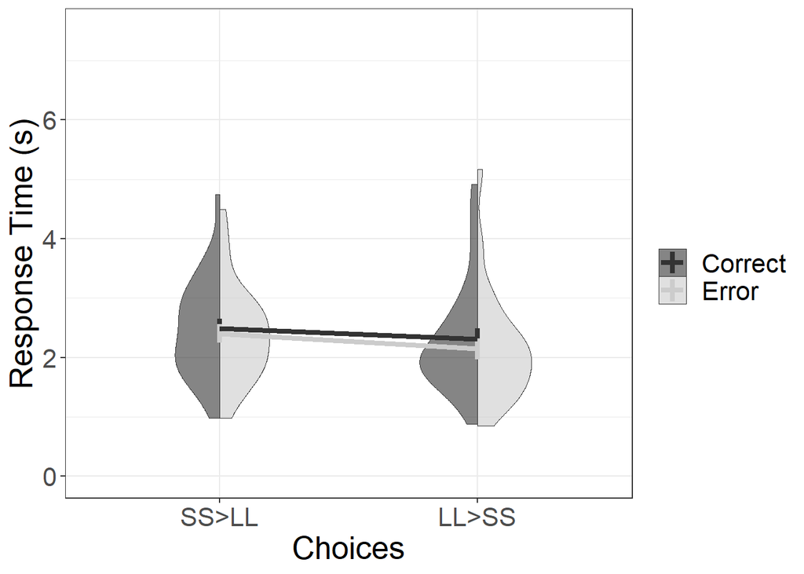

```r
grouped_LLcorrect$LLexpected=1
grouped_SScorrect$LLexpected=0
grouped = rbind(grouped_LLcorrect, grouped_SScorrect)
grouped$rt = grouped$rt/1000
grouped$LLexpected = factor(grouped$LLexpected)
grouped$errorTrial = factor(grouped$errorTrial)
grouped$errorTrial = mapvalues(grouped$errorTrial,
          from = c(0, 1),
          to = c("Correct", "Error"))


ggplot(grouped, aes(x=LLexpected, y=rt, fill=errorTrial)) +
  geom_split_violin(alpha=.6, size=0, position=position_dodge(0)) +
  stat_summary(
      fun.data="mean_se",
      geom="linerange",
      aes(color=errorTrial),
      alpha=1,
      size=1.5) +
  stat_summary(
      fun=mean,
      geom="line",
      aes(group=errorTrial, color=errorTrial),
      size=1.5) +
  # geom_text(x=2, y=7.4, label="***",size=10) +
  coord_cartesian(ylim=c(0,7.5)) +
  theme_bw() +
  theme(text=element_text(size=20)) +
  scale_x_discrete(labels=c("SS>LL", "LL>SS")) +
  xlab("Choices") + ylab("Response Time (s)") +
  labs(fill="",color="")+
  guides(size="none") +
  scale_colour_grey() + scale_fill_grey()
```

```r
ggsave("plots/errRT.pdf",width=6.5, height=5)
```

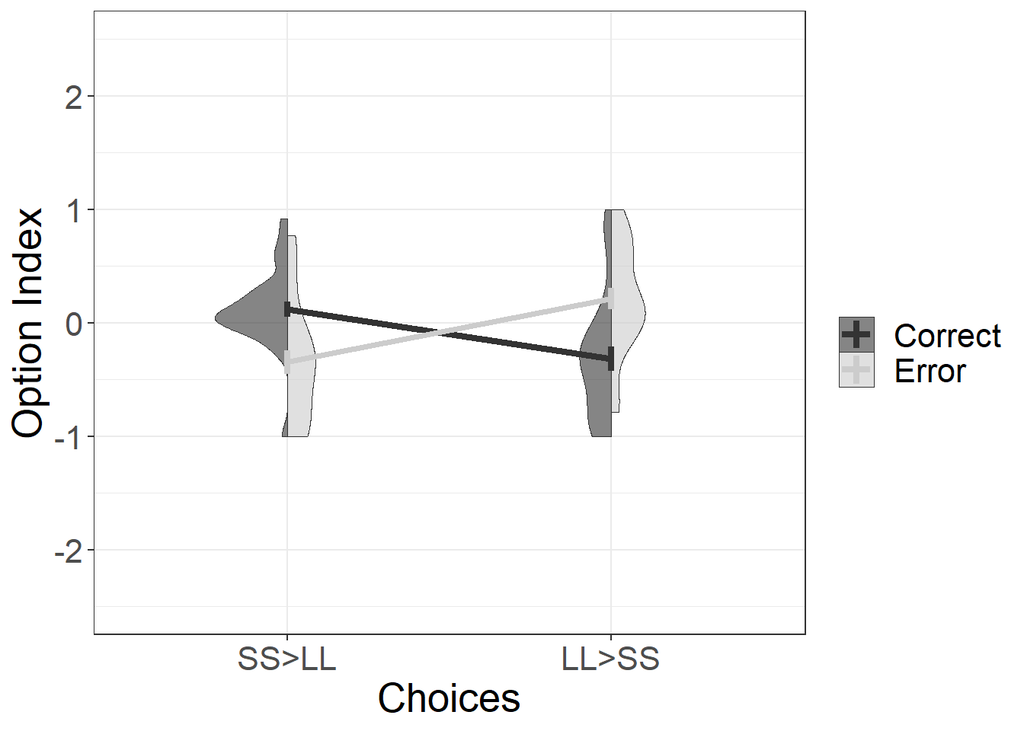

```r
grouped_LLcorrect$LLexpected=1
grouped_SScorrect$LLexpected=0
grouped = rbind(grouped_LLcorrect, grouped_SScorrect)
grouped$rt = grouped$rt/1000
grouped$LLexpected = factor(grouped$LLexpected)
grouped$errorTrial = factor(grouped$errorTrial)
grouped$errorTrial = mapvalues(grouped$errorTrial,
          from = c(0, 1),
          to = c("Correct", "Error"))

ggplot(grouped, aes(x=LLexpected, y=optionIndex, fill=errorTrial)) +
  geom_split_violin(alpha=.6, size=0, position=position_dodge(0)) +
  stat_summary(
      fun.data="mean_se",
      geom="linerange",
      aes(color=errorTrial),
      alpha=1,
      size=1.5) +
  stat_summary(
      fun=mean,
      geom="line",
      aes(group=errorTrial, color=errorTrial),
      size=1.5) +
  # geom_text(x=2, y=7.4, label="***",size=10) +
  coord_cartesian(ylim=c(-2.5, 2.5)) +
  theme_bw() +
  theme(text=element_text(size=20)) +
  scale_x_discrete(labels=c("SS>LL", "LL>SS")) +
  xlab("Choices") + ylab("Option Index") +
  labs(fill="",color="")+
  guides(size="none") +
  scale_colour_grey() + scale_fill_grey()
```

```r
ggsave("plots/errOptInd.pdf",width=6.5, height=5)
```